# Assignment 3

Wai Zin Linn

#### Due Friday, February 12, 11:59 PM CT

### Problems

The following R chunk reads in the exoplanet data.

```r
## Read in the csv file
## There is one row per exoplanet after applying `filter(default_flag != 0)`
## Select some variables that we will work with and rename them
planets <- read_csv("../../data/exoplanets-3sept2020.csv") %>%
  filter(default_flag != 0) %>%
  select(pl_name, discoverymethod, disc_year, sy_pnum, pl_rade, pl_bmasse) %>%
  rename(name=pl_name, method=discoverymethod,year=disc_year, number=sy_pnum, radius=pl_rade, mass=pl_bmasse)
```

### 1

The following block of code creates a new data frame from the `planets` table, and then makes two different scatter plots of log10(mass) versus year. Run the code and then answer the questions noted below chunk.

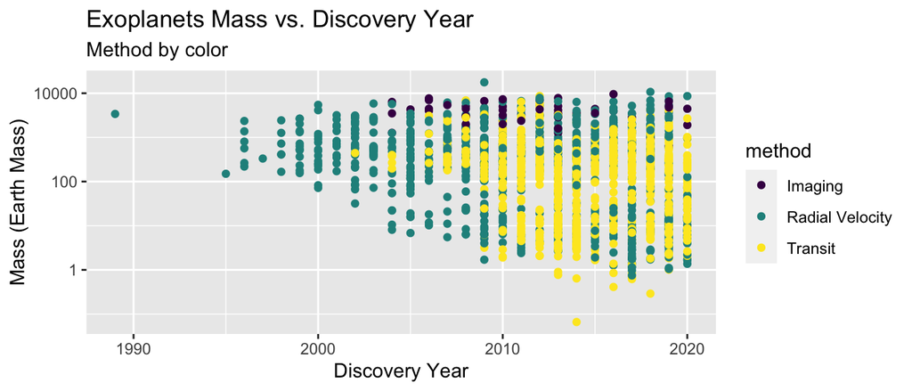

```r
planets_mass <- planets %>%
  select(mass,year,method) %>%
  filter(method %in% c("Radial Velocity", "Imaging", "Transit")) %>%
  drop_na() # drop missing values after selecting the variables we will use for the plots

ggplot(planets_mass, aes(x = year, y = mass, color = method)) +
  geom_point() +
  scale_y_log10() +
  xlab("Discovery Year") +
  ylab("Mass (Earth Mass)") +
  ggtitle("Exoplanets Mass vs. Discovery Year",
          subtitle="Method by color")
```

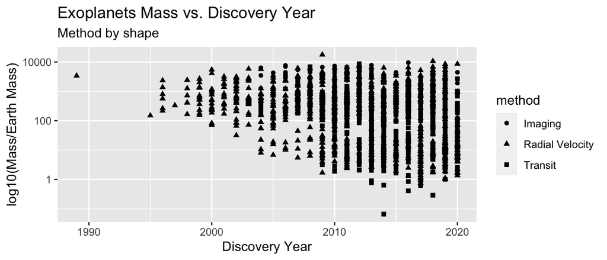

```r
ggplot(planets_mass, aes(x = year, y = mass, shape = method)) +
  geom_point() +
  scale_y_log10() +
  xlab("Discovery Year") +
  ylab("log10(Mass/Earth Mass)") +
  ggtitle("Exoplanets Mass vs. Discovery Year",
          subtitle="Method by shape")
```

> Describe the differences between the two plots.

The first plot is using color differentiation technique instead of shapes. Therefore, different methods are categorized with different colors.For the second plot, it is using shape differentiation technique. Therefore, different methods are categorized with different shapes.

> Which do you think is a more effective at conveying the information and why?

I believe color differentiation technique (graph 1) is more effective at conveying the information because the points are too clustered up when using shape method to differentiate the points. At picture 1, I am able to notice some miscolor happening instead of the points clustering over each other with little differences (picture 2).

### 2

Using the exoplanet data table `planets`, select the variables, `year`, `radius`, and `number`, then remove observations with missing values. Then make a graphic that satisfies the following:

- Make a scatter plot with discovery year on the x axis and radius on the log10 scale on the y-axis.
- Use a different facet for each number. Recall that `number` indicates the number of exoplanets discovered orbiting the same star; this is referred to as the size of the exoplanet system.
- Set the argument `position` within the `geom_point()` command using the command `position_jitter()` so that points are jittered horizontally, but not vertically. Choose an amount of jitter so that there is a reduction in overplotting, but all points for a single year appear as a band without overlap with other years.
- Add descriptive axis labels and a title.

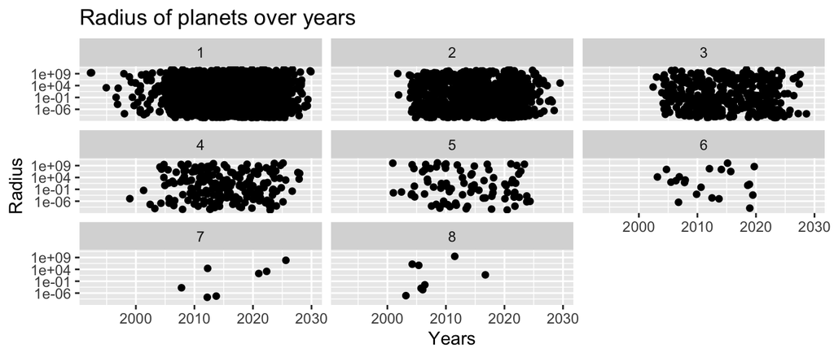

```r
planets_data <- planets %>%
  select(year,radius,number) %>%
  drop_na()

ggplot(planets_data,aes(x=year,y=radius)) +
  geom_point(position = position_jitter(width=10,height=10))+
  scale_y_log10()+
  facet_wrap(~number)+
  xlab("Years")+
  ylab("Radius")+
  ggtitle("Radius of planets over years")
```

### 3

Using the exoplanet data table `planets`, select the variable `method`, then remove observations with missing values. Then make a graphic that satisfies the following:

- Make a bar graph of the method variable that displays the count of the number of observations for each method.
- Use `theme(axis.text.x = element_text(angle = 60, hjust = 1))` to adjust the orientation of the x-axis text. You may adjust the `angle` and `hjust` values if you would like to in order to improve the legibility of the tick mark labels.
- Add descriptive axis labels and a title.

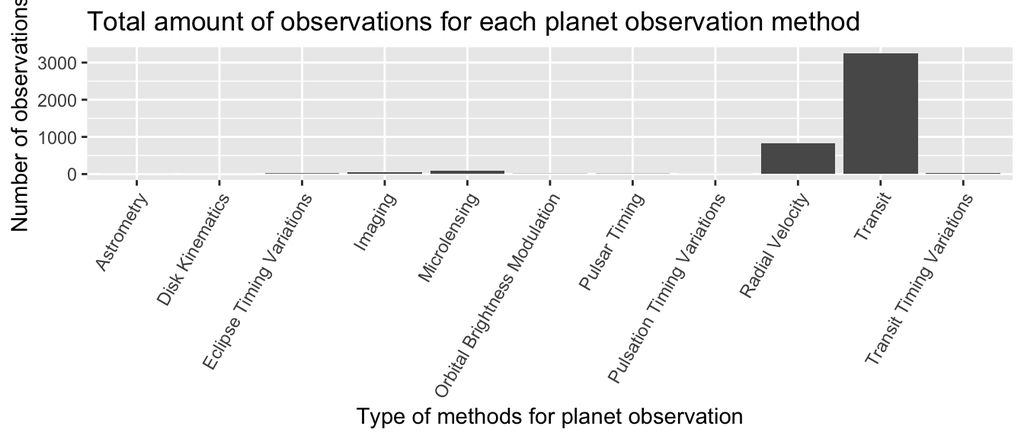

```r
obser_method <- planets %>%
  select(method) %>%
  drop_na()

ggplot(obser_method,aes(x=method)) +
  geom_bar()+
  theme(axis.text.x = element_text(angle = 60, hjust = 1))+
  xlab("Type of methods for planet observation")+
  ylab("Number of observations")+
  ggtitle("Total amount of observations for each planet observation method")
```

### 4

Repeat the previous problem, but replace the counts on the y-axis with proportions. (*Hint:* You need to set the `y` aesthetic to `stat(prop)` and the group aesthetic to `1`. See the second example in R4DS section 3.7.)

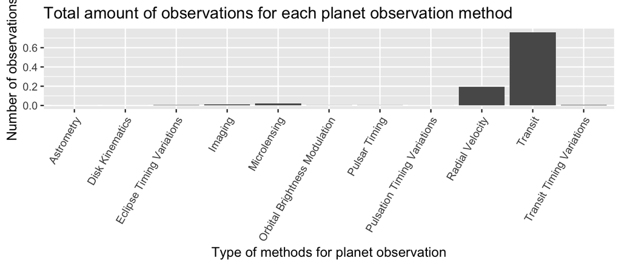

```r
ggplot(obser_method) +
  geom_bar(mapping = aes(x=method, y = stat(prop),group=1))+
  theme(axis.text.x = element_text(angle = 60, hjust = 1))+
  xlab("Type of methods for planet observation")+
  ylab("Number of observations")+
  ggtitle("Total amount of observations for each planet observation method")
```

### 5

The following block of code reads in the raw Lake Mendota data and makes several transformations. Examine indicated sections of the code and answer the corresponding questions listed below the chunk.

```r
mendota_interval <- read_csv("../../data/lake-mendota-raw.csv") %>%
## question (a) begin
  select(-days) %>%
## question (a) end
## question (b) begin
  drop_na() %>%
## question (b) end
## question (c) begin
  separate(winter,into = c("year1","year2"), remove = FALSE) %>%
  mutate(year1 = as.numeric(year1)) %>%
  mutate(year2 = year1+1) %>%
## question (c) end
  mutate(closed = case_when(
    str_detect(closed,"Oct|Nov|Dec") ~ str_c(closed,' ',year1),
    str_detect(closed,"Jan|Feb|Mar|Apr|May") ~ str_c(closed,' ',year2),
    TRUE ~ NA_character_
  )) %>%
  mutate(closed = dmy(closed)) %>%
  mutate(open = case_when(
    str_detect(open,"Oct|Nov|Dec") ~ str_c(open,' ',year1),
    str_detect(open,"Jan|Feb|Mar|Apr|May") ~ str_c(open,' ',year2),
    TRUE ~ NA_character_
  )) %>%
  mutate(open = dmy(open)) %>%
  mutate(days = open - closed)

mendota <- mendota_interval %>%
## question (d) begin
  group_by(winter) %>%
  summarize(intervals = n(),
            days = sum(days),
            first_freeze = min(closed),
            last_thaw = max(open)) %>%
## questions (d) end
  mutate(year1 = as.numeric(str_sub(winter,1,4))) %>%
  mutate(decade = floor(year1 / 10) * 10) %>%
  select(winter,year1,everything())
```

#### (a)

> What does the line `select(-days)` do to the data set?

Remove the column of days data set.

#### (b)

> What does the command `drop_na()` do? How many rows (observations) are in the data set when it is first read in and how many rows remain after this code is executed?

Originally, there are 175 observations. After the drop_na() command, there are only 172 observations left.

#### (c)

> Describe the effect these three lines of code have on the data set

It adds two new columns year1 and year2. Year1 lists out the starting year of that corresponding winter of and years2 lists out the closing year of that corresponding winter.

#### (d)

> Explain what the effect of these two commands are. In your response, describe what the effect of the `group_by(winter)` command is, what the function `n()` does, and what the functions `sum()`, `min()`, and `max()` do.

group_by(winter) will group the mendota_interval dataframe as winter. n() would just count the numbers of winter at a corresponding year. sum() would add up the number of days in a corresponding winter. min() would find the minimum date for the each winter’s closed date. max() would find the maximum date for each winter’s open date.

### 6

> Explain the difference between the `geom_col()` and `geom_bar()` functions.

geom_bar() uses stat_count() to draw the number of cases in each group. While, geom_col() uses stat_identity() to draw the values for each group.